# PracticalMachineLearningProject

Heemeng Foo

11/3/2017

# Practical Machine Learning Course Project

The objective of the project is to create a Machine Learning algorithm to properly classify the quality of barbell bicep curls by using data from belt, forearm, arm, and dumbbell monitors. The 5 classifications of this exercise are: (A) the correct form of the exercise, (B) throwing elbows to the front, (C) lifting dumbbell up, (D) lowering dumbbell down and (E) throwing hips to the front.

http://groupware.les.inf.puc-rio.br/har#ixzz3PO5pnm1R

## Setting up libraries

```r
library(caret)
library(gridExtra)
```

## Reading in raw data

```r
trainingRaw <- read.csv("pml-training.csv")
testingRaw <- read.csv("pml-testing.csv")
```

## Cleaning up training and testing data set

Most of the data are not very useful with a lot of NAs so good idea to subset the data sets, reducing to 52 variables

```r
trainingSub <- subset(trainingRaw, select = grep("^accel|^total|^roll|^pitch|^yaw|^magnet|^gyro", names(trainingRaw)))
testingSub <- subset(testingRaw, select = grep("^accel|^total|^roll|^pitch|^yaw|^magnet|^gyro", names(testingRaw)))
trainingSub$Classe = trainingRaw$classe
testingSub$problem.id = testingRaw$problem_id
```

### clearing memory

```r
rm(trainingRaw, testingRaw)
```

## Creating data partitions within the training data set so that we can perform cross validation

```r
set.seed("999")
inTrain <- createDataPartition(y=trainingSub$Classe, p=0.7, list=FALSE)
training <- trainingSub[inTrain,]
testing <- trainingSub[-inTrain,]
```

## Decision tree technique

```r
modFit <- train(Classe ~., method="rpart", data=training)
```

### Analyse model

```r
print(modFit$finalModel)
```

```
## n= 13737
##
## node), split, n, loss, yval, (yprob)
##       * denotes terminal node
##
##  1) root 13737 9831 A (0.28 0.19 0.17 0.16 0.18)
##    2) roll_belt< 130.5 12620 8724 A (0.31 0.21 0.19 0.18 0.11)
##      4) pitch_forearm< -33.65 1111    9 A (0.99 0.0081 0 0 0) *
##      5) pitch_forearm>=-33.65 11509 8715 A (0.24 0.23 0.21 0.2 0.12)
##       10) magnet_dumbbell_y< 439.5 9713 6977 A (0.28 0.18 0.24 0.19 0.11)
##         20) roll_forearm< 123.5 6018 3565 A (0.41 0.18 0.18 0.17 0.06) *
##         21) roll_forearm>=123.5 3695 2468 C (0.077 0.17 0.33 0.23 0.19) *
##       11) magnet_dumbbell_y>=439.5 1796  886 B (0.032 0.51 0.043 0.22 0.2) *
##    3) roll_belt>=130.5 1117   10 E (0.009 0 0 0 0.99) *
```

### Plotting partition (using plot as rattle can’t install on my box)

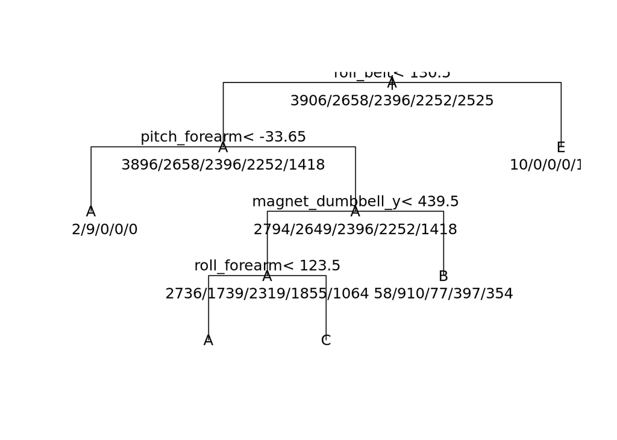

```r
plot(modFit$finalModel, uniform = TRUE)
text(modFit$finalModel, use.n=TRUE, all=TRUE)
```

### Prediction

```r
pred <- predict(modFit, testing)
confusionMatrix(testing$Classe, pred)
```

```
## Confusion Matrix and Statistics
##
##           Reference
## Prediction    A    B    C    D    E
##          A 1527   23  120    0    4
##          B  473  376  290    0    0
##          C  495   31  500    0    0
##          D  441  171  352    0    0
##          E  163  132  263    0  524
##
## Overall Statistics
##
##                Accuracy : 0.4974
##                  95% CI : (0.4845, 0.5102)
##     No Information Rate : 0.5266
##     P-Value [Acc > NIR] : 1
##
##                   Kappa : 0.3425
##  Mcnemar's Test P-Value : NA
##
## Statistics by Class:
##
##                      Class: A Class: B Class: C Class: D Class: E
## Sensitivity            0.4927  0.51296  0.32787       NA  0.99242
## Specificity            0.9472  0.85190  0.87936   0.8362  0.89584
## Pos Pred Value         0.9122  0.33011  0.48733       NA  0.48429
## Neg Pred Value         0.6267  0.92478  0.78905       NA  0.99917
## Prevalence             0.5266  0.12455  0.25913   0.0000  0.08972
## Detection Rate         0.2595  0.06389  0.08496   0.0000  0.08904
## Detection Prevalence   0.2845  0.19354  0.17434   0.1638  0.18386
## Balanced Accuracy      0.7200  0.68243  0.60361       NA  0.94413
```

Results are not good. Accuracy is under 50% which is worse than a coin toss! Also note from plot there is no path to class D

## Naive Bayes approach

```r
modFit2 <- suppressWarnings(train(Classe ~., method="nb", data=training))
print(modFit2)
```

```
## Naive Bayes
##
## 13737 samples
##    52 predictors
##     5 classes: 'A', 'B', 'C', 'D', 'E'
##
## No pre-processing
## Resampling: Bootstrapped (25 reps)
## Summary of sample sizes: 13737, 13737, 13737, 13737, 13737, 13737, ...
## Resampling results across tuning parameters:
##
##   usekernel  Accuracy   Kappa
##   FALSE      0.5595334  0.4445315
##    TRUE      0.7451579  0.6794072
##
## Tuning parameter 'fL' was held constant at a value of 0
## Tuning
##  parameter 'adjust' was held constant at a value of 1
## Accuracy was used to select the optimal model using  the largest value.
## The final values used for the model were fL = 0, usekernel = TRUE
##  and adjust = 1.
```

```r
pred2 <- predict(modFit2, testing)
```

```r
confusionMatrix(testing$Classe, pred2)
```

```
## Confusion Matrix and Statistics
##
##           Reference
## Prediction    A    B    C    D    E
##          A 1230   51  179  195   19
##          B   88  791  160   86   14
##          C   52   65  871   36    2
##          D   39    5  180  698   42
##          E   29   85   58   29  881
##
## Overall Statistics
##
##                Accuracy : 0.7597
##                  95% CI : (0.7486, 0.7706)
##     No Information Rate : 0.246
##     P-Value [Acc > NIR] : < 2.2e-16
##
##                   Kappa : 0.6981
##  Mcnemar's Test P-Value : < 2.2e-16
##
## Statistics by Class:
##
##                      Class: A Class: B Class: C Class: D Class: E
## Sensitivity            0.8554   0.7934   0.6015   0.6686   0.9196
## Specificity            0.9002   0.9288   0.9651   0.9451   0.9592
## Pos Pred Value         0.7348   0.6945   0.8489   0.7241   0.8142
## Neg Pred Value         0.9506   0.9566   0.8813   0.9297   0.9840
## Prevalence             0.2444   0.1694   0.2460   0.1774   0.1628
## Detection Rate         0.2090   0.1344   0.1480   0.1186   0.1497
## Detection Prevalence   0.2845   0.1935   0.1743   0.1638   0.1839
## Balanced Accuracy      0.8778   0.8611   0.7833   0.8068   0.9394
```

Accuracy is encouraging - 76%

## Random Forest technique

```r
modFit3 <- train(Classe ~., method="rf", data=training)
print(modFit3)
```

```
## Random Forest
##
## 13737 samples
##    52 predictors
##     5 classes: 'A', 'B', 'C', 'D', 'E'
##
## No pre-processing
## Resampling: Bootstrapped (25 reps)
## Summary of sample sizes: 13737, 13737, 13737, 13737, 13737, 13737, ...
## Resampling results across tuning parameters:
##
##   mtry  Accuracy   Kappa
##    2    0.9883867  0.9853068
##   27    0.9878499  0.9846283
##   52    0.9759066  0.9695167
##
## Accuracy was used to select the optimal model using  the largest value.
## The final value used for the model was mtry = 2.
```

```r
pred3 <- predict(modFit3, testing)
confusionMatrix(testing$Classe, pred3)
```

```
## Confusion Matrix and Statistics
##
##           Reference
## Prediction    A    B    C    D    E
##          A 1674    0    0    0    0
##          B    6 1130    3    0    0
##          C    0    7 1017    2    0
##          D    0    0   14  949    1
##          E    0    0    0    1 1081
##
## Overall Statistics
##
##                Accuracy : 0.9942
##                  95% CI : (0.9919, 0.996)
##     No Information Rate : 0.2855
##     P-Value [Acc > NIR] : < 2.2e-16
##
##                   Kappa : 0.9927
##  Mcnemar's Test P-Value : NA
##
## Statistics by Class:
##
##                      Class: A Class: B Class: C Class: D Class: E
## Sensitivity            0.9964   0.9938   0.9836   0.9968   0.9991
## Specificity            1.0000   0.9981   0.9981   0.9970   0.9998
## Pos Pred Value         1.0000   0.9921   0.9912   0.9844   0.9991
## Neg Pred Value         0.9986   0.9985   0.9965   0.9994   0.9998
## Prevalence             0.2855   0.1932   0.1757   0.1618   0.1839
## Detection Rate         0.2845   0.1920   0.1728   0.1613   0.1837
## Detection Prevalence   0.2845   0.1935   0.1743   0.1638   0.1839
## Balanced Accuracy      0.9982   0.9960   0.9909   0.9969   0.9994
```

Accuracy is good - 99%, specificity and sensitivity also good - 99%

```r
varImp(modFit3)
```

```
## rf variable importance
##
##   only 20 most important variables shown (out of 52)
##
##                      Overall
## roll_belt             100.00
## yaw_belt               71.62
## magnet_dumbbell_z      66.48
## magnet_dumbbell_y      59.69
## pitch_belt             58.74
## pitch_forearm          54.82
## roll_forearm           50.25
## magnet_dumbbell_x      47.28
## magnet_belt_z          40.54
## accel_dumbbell_y       39.99
## magnet_belt_y          39.55
## accel_belt_z           39.41
## roll_dumbbell          37.89
## accel_dumbbell_z       33.55
## accel_forearm_x        32.98
## roll_arm               30.83
## total_accel_dumbbell   28.80
## gyros_belt_z           28.73
## gyros_dumbbell_y       28.18
## yaw_dumbbell           27.60
```

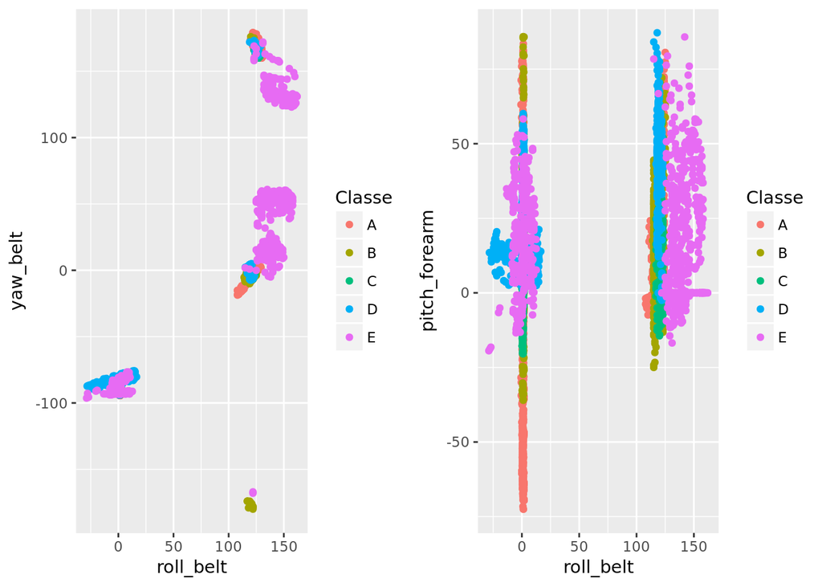

```r
plot1 <- qplot(roll_belt,yaw_belt,colour=Classe,data=testing)
plot2 <- qplot(roll_belt,pitch_forearm,colour=Classe,data=testing)
grid.arrange(plot1, plot2, ncol=2)
```

## Checking In Sample error

```r
inpred <- predict(modFit3, training)
confusionMatrix(training$Classe, inpred)
```

```
## Confusion Matrix and Statistics
##
##           Reference
## Prediction    A    B    C    D    E
##          A 3906    0    0    0    0
##          B    0 2658    0    0    0
##          C    0    0 2396    0    0
##          D    0    0    0 2252    0
##          E    0    0    0    0 2525
##
## Overall Statistics
##
##                Accuracy : 1
##                  95% CI : (0.9997, 1)
##     No Information Rate : 0.2843
##     P-Value [Acc > NIR] : < 2.2e-16
##
##                   Kappa : 1
##  Mcnemar's Test P-Value : NA
##
## Statistics by Class:
##
##                      Class: A Class: B Class: C Class: D Class: E
## Sensitivity            1.0000   1.0000   1.0000   1.0000   1.0000
## Specificity            1.0000   1.0000   1.0000   1.0000   1.0000
## Pos Pred Value         1.0000   1.0000   1.0000   1.0000   1.0000
## Neg Pred Value         1.0000   1.0000   1.0000   1.0000   1.0000
## Prevalence             0.2843   0.1935   0.1744   0.1639   0.1838
## Detection Rate         0.2843   0.1935   0.1744   0.1639   0.1838
## Detection Prevalence   0.2843   0.1935   0.1744   0.1639   0.1838
## Balanced Accuracy      1.0000   1.0000   1.0000   1.0000   1.0000
```

```r
answer <- predict(modFit3, testingSub)
print(answer)
```

```
##  [1] B A B A A E D B A A B C B A E E A B B B
## Levels: A B C D E
```

## Conclusion

The Random Forest approach was by far the superior technique over both Decision Tree (ie. rpart) and Naive Baysian approaches. Of the 5 classes, C and D are the most difficult to differentiate but Random Forest method gives the best result.